# Final Project, Winter 2024

Author

Michelle Trim

**Project Background:** There are multiple pathways for students to access the computer science and informatics major at UMass. Both majors are ‘closed’ majors which means that students must apply to the major either via the UMass admissions process or via an internal major change once already enrolled at UMass. Both methods are very competitive. Computer Science as a field struggles with diversity of representation as women and people from historically marginalized groups are significantly underrepresented in the field. One general hypothesis suggests that by making Computer Science more competitive, the discipline becomes less appealing to those who already have to overcome disadvantages due to their marginalized status in the field and within society. Another dimension of marginalization that has historically been difficult to measure is economic class. While not a perfect correlation, my studies over the past few years have shown that those from wealthier backgrounds are more likely to have attended a high school in the US offering Advanced Placement courses and access to the Advanced Placement test for Computer Science, known as AP CSA. The first part of my studies began with an observation that a large number of students enter the CS major via admissions with AP credit for computer science. In previous work, I engaged in hypothesis testing to determine if students entering the final programming course via AP credit performed the same or differently than those students who entered that class via the normal pre-requisite course here at UMass.

Within the CS and Informatics majors, there are introductory programming classes that all students must take. Students score either a 4 or 5 on the CS A AP exam may enter 187 (the final course in the programming sequence at the time of my prior study) as newly admitted students. These AP scores are considered evidence of equivalent skill mastery to that achieved from the posted pre-requisites for the course. As a result, the null hypothesis would have been that there should be no difference in performance when comparing the grade mean of one group (the AP group) with the the other group (the pre-requisite class group). In my analysis, I learned that within a 99% confidence interval and p-value of .005, students who entered 187 via the AP exam are likely to have a higher grade in 187 by at least a .5 difference. In sum, the means for both groups are different, and I reject the null hypothesis.

Having learned that there is some evidence to suggest that students entering with AP exam credit for computer science have a performance advantage, and seeing that one third to one half of all entering CS majors have AP CSA credit, I wondered if there is an admissions advantage to having this AP credit and if that advantage is corresponding to a particular identity feature, such as economic class.

**Research Question:** I want to know who has access to the AP CSA exam and if this access is prioritizing students with particular identity features. In this case, a null hypothesis might be that access to the CS AP is not determined based on race, gender, or economic class as the public school system in Massachusets is required to serve all students equally, and AP computer science is a class that has existed in the public school system for decades. In order to explore this research question, I need to be able to explore data on AP CSA access and performance that enables me to make correlations between that access and performance to identity features of the students taking these exams. The State of Massachusetts does publish data on all AP exam results, by school district, and broken down by race and gender. The State also publishes data on the school districts themselves, including their funding status/amounts, graduation rates, and size of their senior cohorts.

**Data Exploration:** To begin, I am importing a large dataset from the 2022-2023 AP exam test statistics for the state of Massachusetts, broken down by school district name. There are multiple data sets as the site permits some tailoring of the data according to various selection criteria. One challenge of this data is that AP Performance is not reported for enrollments of fewer than 10 per district. That data can be accessed at the following URL where one has to set the selection for year before generating an automatic download of a .csv file. (see this website to generate a download of the CSV file used: https://profiles.doe.mass.edu/statereport/ap.aspx).

I now have a dataset that contains the scores by school district for the AP CSA exam (the exam that results in credit for introductory programming) These data are also located in CSV files with one file per demographic criteria.

This dataset that I am starting with has one categorical column which lists the school district name, a numerical column listing the district’s identifier code, the number of tests taken at the district as an integer, and the next five columns are the number of tests that earned a one, two, three, four or five. The last two columns are float/double columns that provide the percentage of tests taken at that district that earned either a failing score of a 1 or 2 or a passing score of 3,4,or 5. One way I will need to mutate the data is to create a new column that is percent of just 4 and 5 as UMass rarely accepts 3s as passing for any AP exam.This also has numeric variables such as expenditures per student, graduation rate, size of the senior cohort, and dropout rate.

Via an online search, I was able to learn that there are 306 total school districts in the state of Massachusetts, but not all offer the CS AP exam, and not all include high schools. One of the variables I want to examine has to do with school funding. One hypothesis is that higher funded schools are more likely to have AP exams available, and a further extrapolation of that assumption is that higher funded schools would be more likely to have their students earn 4s and 5s (scores most likely to result in receiving course completion credit at public universities) on their AP exams. I was able to find State of Massachusetts data on state expenditures per student per school district. I am going to use that information as a proxy for wealthy/well funded school district instead of using property values as I think there is a lesser chance of confounding variables being hidden in using state spending per student rather than using the likely source of the funding for that spending (property values). The downside to using this proxy is that it treats school districts as one entity and some districts may have more than one highschool, and each of those schools may have different spending per student values. I accessed this dataset at this URL where I selected the year before it automatically downloaded the resulting .CSV file: (https://profiles.doe.mass.edu/statereport/ppx.aspx)

I merged these data sets (CSA AP and State District expenditures and senior cohort information (see this site to make selections and generate a .csv file of each cohort’s graduation report:https://profiles.doe.mass.edu/statereport/gradrates.aspx ) using the unique school district code identifiers in MS excel because that was the fastest/most efficient process. The resulting dataset includes expenditure data, CSA AP data, and data on size of cohort and rate of graduation as mentioned above, but only for the districts that had CSA tests taken in the 2022-2023 school year. Scores of 1 or 2 on the CSA AP exam are almost always failing scores, and the values in those columns are counts - the number of tests taken with that score. Similarly, sometimes a 3 score and always a 4 or or a 5 score are considered ‘passing’ scores and thus likely to result in AP credit at most colleges. The percent 1_2 and percent3_4_5 scores are percentages of tests taken at the district that earned one of those scores. As a reminder, detailed data on the score counts and rates for specific district’s CSA AP tests taken are not included by the State when fewer than 10 exams were taken in that district and so those values are ’na’s in the dataset.

```
[1] 158  22
```

```
 District Name      District Code      In-District Expenditures
 Length:158         Min.   :   90000   Min.   :3.972e+06
 Class :character   1st Qu.: 1452500   1st Qu.:3.028e+07
 Mode  :character   Median : 2445000   Median :4.904e+07
                    Mean   : 3472658   Mean   :7.480e+07
                    3rd Qu.: 4877500   3rd Qu.:8.109e+07
                    Max.   :35060000   Max.   :1.349e+09
                                       NA's   :1
 Total In-district FTEs In-District Expenditures per Pupil Total Expenditures
 Min.   :  218.7        Min.   :13539                      Min.   :3.972e+06
 1st Qu.: 1596.1        1st Qu.:16059                      1st Qu.:3.288e+07
 Median : 2699.1        Median :17761                      Median :5.388e+07
 Mean   : 3941.6        Mean   :18667                      Mean   :8.438e+07
 3rd Qu.: 4695.1        3rd Qu.:20263                      3rd Qu.:9.348e+07
 Max.   :48747.8        Max.   :33555                      Max.   :1.677e+09
 NA's   :1              NA's   :1                          NA's   :1
 Total Pupil FTEs  total_expenditures_per_pupil CSATestsTaken
 Min.   :  218.7   Min.   :14566                Min.   :  1.00
 1st Qu.: 1694.8   1st Qu.:16921                1st Qu.:  5.00
 Median : 2809.3   Median :18322                Median : 11.00
 Mean   : 4298.6   Mean   :19347                Mean   : 16.16
 3rd Qu.: 5068.0   3rd Qu.:20941                3rd Qu.: 19.75
 Max.   :63064.7   Max.   :35114                Max.   :147.00
 NA's   :1         NA's   :1
   one_score        two_score       three_score       four_score
 Min.   : 0.000   Min.   : 0.000   Min.   : 0.000   Min.   : 0
 1st Qu.: 1.000   1st Qu.: 1.000   1st Qu.: 2.000   1st Qu.: 2
 Median : 4.000   Median : 2.000   Median : 3.000   Median : 4
 Mean   : 5.565   Mean   : 2.271   Mean   : 4.447   Mean   : 6
 3rd Qu.: 7.000   3rd Qu.: 3.000   3rd Qu.: 6.000   3rd Qu.: 8
 Max.   :43.000   Max.   :12.000   Max.   :26.000   Max.   :44
 NA's   :73       NA's   :73       NA's   :73       NA's   :73
   five_score       percent_12    percent_345    Senior_cohort
 Min.   : 0.000   Min.   : 0.0   Min.   : 12.5   Min.   :  37.0
 1st Qu.: 1.000   1st Qu.:10.0   1st Qu.: 35.8   1st Qu.: 155.8
 Median : 3.000   Median :30.0   Median : 70.0   Median : 242.5
 Mean   : 8.012   Mean   :35.9   Mean   : 64.1   Mean   : 321.2
 3rd Qu.:12.000   3rd Qu.:64.2   3rd Qu.: 90.0   3rd Qu.: 387.2
 Max.   :84.000   Max.   :87.5   Max.   :100.0   Max.   :3867.0
 NA's   :73       NA's   :73     NA's   :73
  percent_grad   percent_stillinschool percent_nongrad  percentHSequiv
 Min.   :77.20   Min.   : 0.000        Min.   :0.0000   Min.   :0.0000
 1st Qu.:90.83   1st Qu.: 1.700        1st Qu.:0.0000   1st Qu.:0.0000
 Median :94.80   Median : 2.800        Median :0.0000   Median :0.0000
 Mean   :92.99   Mean   : 3.541        Mean   :0.2867   Mean   :0.3057
 3rd Qu.:96.88   3rd Qu.: 4.900        3rd Qu.:0.3000   3rd Qu.:0.4000
 Max.   :99.40   Max.   :13.100        Max.   :3.8000   Max.   :5.4000

 percentDroppedout
 Min.   : 0.000
 1st Qu.: 0.700
 Median : 1.800
 Mean   : 2.872
 3rd Qu.: 3.875
 Max.   :13.300
```

My data has 158 rows (school districts) and 22 columns. I still have a number of NAs in the score performance columns. This is due to the state not reporting detailed results when school districts have fewer than 10 AP exams completed. The above summary also shows me that the the median graduation rate in the state among those students who took the CSA exam is very high - 95%. This value is a long way from the 77.2 percent minimum in any one school district. Also of interest is the small number of tests taken. Despite the median senior cohort size being 242 students, the median number of CSA exams taken is only 11. This is very interesting to me. As computer science is the largest undergraduate major at UMass, it seems surprising that only about 5% proportionately of Massachusetts seniors are taking the AP exam for CS, suggesting a very small percentage of students are pursuing computer science in high school OR do not have access to the exam. One possible research question for the future might be to try to explore why this might be the case.

Total expenditures per pupil might be another interesting figure to explore since there is a 20K difference between the minimum and maximum value in the data set. Another research question might ask what relationship is there between the expenditures per student and the number of CSA exams taken? How do those values also correlate or not with the percentage of passing scores on the exam. Just to get a stronger sense of potential correlations, I ran a few plots of different pairs of variables in the set that might have a relationship.

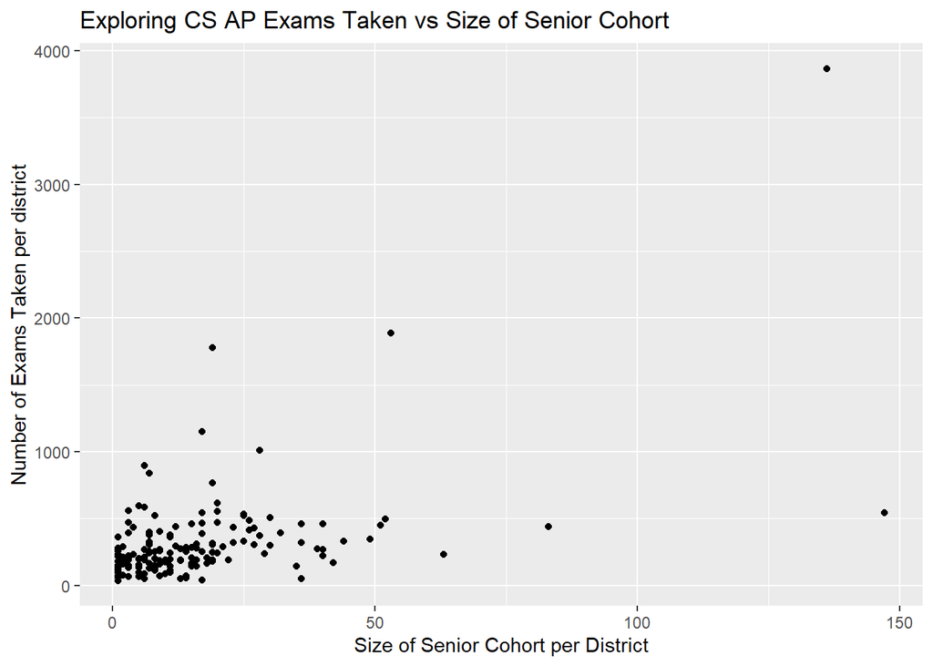

```r
#Exploration plots of various variable relationships in the dataset
CSA_all %>%
  ggplot(aes(x = CSATestsTaken, y = Senior_cohort)) + geom_point() + labs(title = "Exploring CS AP Exams Taken vs Size of Senior Cohort", y = "Number of Exams Taken per district", x = "Size of Senior Cohort per District")
```

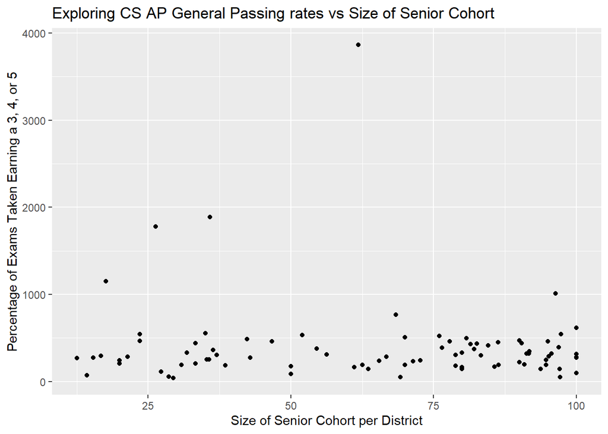

```r
CSA_all%>%
  ggplot(aes(x = percent_345, y = Senior_cohort)) + geom_point() +labs(title = "Exploring CS AP General Passing rates vs Size of Senior Cohort", y = "Percentage of Exams Taken Earning a 3, 4, or 5", x = "Size of Senior Cohort per District")
```

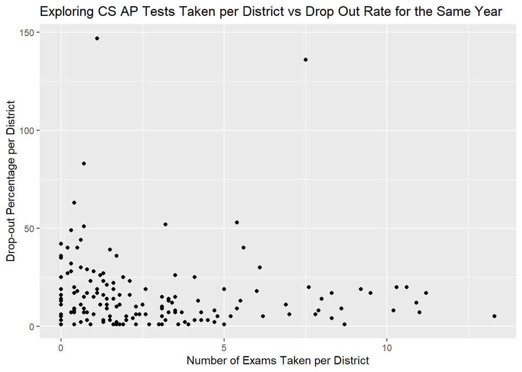

```r
CSA_all %>%
    ggplot(aes(x = percentDroppedout, y = CSATestsTaken)) + geom_point() + labs(title = "Exploring CS AP Tests Taken per District vs Drop Out Rate for the Same Year", y = "Drop-out Percentage per District", x = "Number of Exams Taken per District")
```

Hmm. The three plots ran don’t necessarily convey a strong linear relationship among the specific variables, but they do suggest some clustering and then some potential outlier data points that I would like to explore further. For example, the tests taken vs size of cohort does seem to have a slight positive trend, but there are at least 5 data points that are at some distance from the rest. We see a similar output in terms of potential outliers when we look at the percent of ‘passing’ scores plotted against size of senior cohort, but there is even less of a suggestion of a positive trend. When we plot the percentage drop out rate against the number of tests taken, the result is less conclusive than I expected. I thought we’d see a strong negative relationship, thinking that a school with more dropouts would be less likely to push AP exams, and there is a hit of a downward trend, but again, the few potential outliers, especially around and below 7.5% dropout rate is a little unexpected. I am going to try mutating the data to group some of the scores and reduce the measurement level in the size of the senior cohort to see if I can determine what is causing those distanced points. Are they a result of very large, but diverse school districts? I need to explore further.

```r
#The following is attempting to reduce the measurement of cohort size by creating chunks of school district sizes based on sizes of the senior cohort for that district. The cut-offs for these are somewhat arbitrary.
Senior_chunks <- CSA_all %>%
  as_tibble() %>%
  mutate(
    Senior_cohort=case_when(
      Senior_cohort < 75 ~ "small",
      Senior_cohort > 75 & Senior_cohort < 250 ~ "medium",
      Senior_cohort>250 & Senior_cohort < 500 ~ "large",
      Senior_cohort >500 ~ "extra large"

    )
  )

Senior_chunks
```

```
# A tibble: 158 × 22
   `District Name` `District Code` In-District Expendit…¹ Total In-district FT…²
   <chr>                     <dbl>                  <dbl>                  <dbl>
 1 Acton-Boxborou…         6000000              91293992.                  5219.
 2 Advanced Math …         4300000              16072974.                   964.
 3 Amherst-Pelham          6050000              30276466                   1265.
 4 Andover                   90000             111233153                   5588.
 5 Arlington                100000              97116944.                  5740.
 6 Ashland                  140000              41552193.                  2755.
 7 Assabet Valley…         8010000              28530789.                  1152.
 8 Attleboro                160000              91035634.                  5904.
 9 Auburn                   170000              37360958.                  2509.
10 Ayer Shirley S…         6160000              28878193.                  1596.
# ℹ 148 more rows
# ℹ abbreviated names: ¹`In-District Expenditures`, ²`Total In-district FTEs`
# ℹ 18 more variables: `In-District Expenditures per Pupil` <dbl>,
#   `Total Expenditures` <dbl>, `Total Pupil FTEs` <dbl>,
#   total_expenditures_per_pupil <dbl>, CSATestsTaken <dbl>, one_score <dbl>,
#   two_score <dbl>, three_score <dbl>, four_score <dbl>, five_score <dbl>,
#   percent_12 <dbl>, percent_345 <dbl>, Senior_cohort <chr>, …
```

```r
table(select(Senior_chunks, Senior_cohort))
```

```
Senior_cohort
extra large       large      medium       small
         19          57          64          16
```

Checking my distribution of senior cohorts to reflect logical divisions. The following rough plot is just to check my numbers.

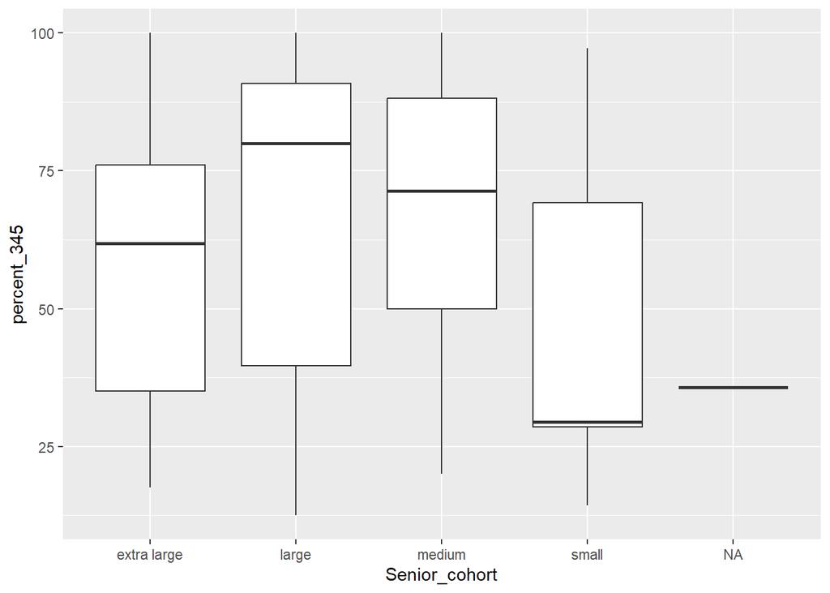

```r
Senior_chunks %>%
  ggplot (aes( x = Senior_cohort, y = percent_345, na.rm = TRUE)) + geom_boxplot()
```

This boxplot is interesting because it helps me visualize the relationship between size of senior cohort and percentage of tests earning a 3 or 4 or 5. This plot shows that there is no super strong correlation between the two - the mean for the small cohorts is strangely low compared to the distribution of the data. But what is interesting is that the 250-500 size cohort does seem to have a slightly higher average percentage of passing scores on this specific AP exam.

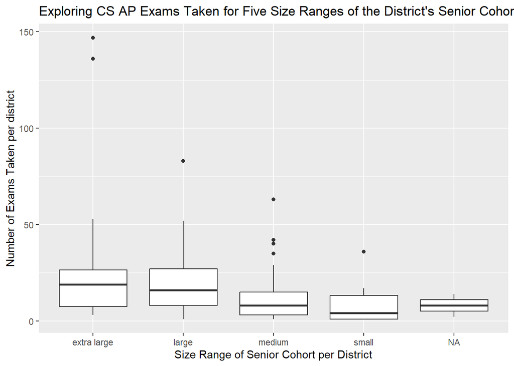

```r
Senior_chunks %>%
  ggplot (aes( x = Senior_cohort, y = CSATestsTaken)) + geom_boxplot() + labs(title = "Exploring CS AP Exams Taken for Five Size Ranges of the District's Senior Cohort", y = "Number of Exams Taken per district", x = "Size Range of Senior Cohort per District")
```

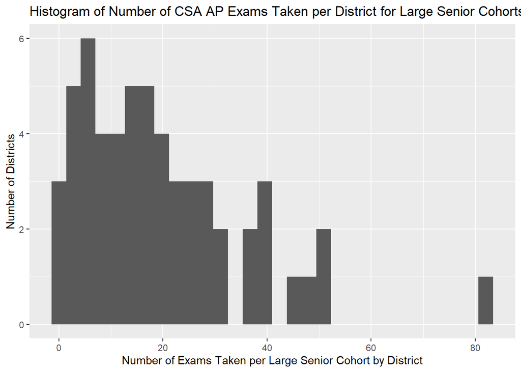

```r
#Plotting a histogram of the number of tests taken when the dataset is filtered to just list the districts with senior cohorts in the large range.
Large_sen_chunk <- filter(Senior_chunks, Senior_cohort == "large")

Large_sen_chunk %>%
  ggplot(aes(CSATestsTaken)) + geom_histogram ()+ labs(title = "Histogram of Number of CSA AP Exams Taken per District for Large Senior Cohorts", y = "Number of Districts", x = "Number of Exams Taken per Large Senior Cohort by District")
```

```r
#sorting by number of tests taken
CSA_all %>%
  arrange(CSATestsTaken) %>%
  tail()
```

```
# A tibble: 6 × 22
  `District Name`  `District Code` In-District Expendit…¹ Total In-district FT…²
  <chr>                      <dbl>                  <dbl>                  <dbl>
1 Cambridge                 490000             222130863.                  6620
2 Worcester                3480000             411191518.                 24019.
3 Wayland                  3150000              54734626.                  2699.
4 Acton-Boxborough         6000000              91293992.                  5219.
5 Boston                    350000            1348915646.                 48748.
6 Lexington                1550000             137855052.                  6884.
# ℹ abbreviated names: ¹`In-District Expenditures`, ²`Total In-district FTEs`
# ℹ 18 more variables: `In-District Expenditures per Pupil` <dbl>,
#   `Total Expenditures` <dbl>, `Total Pupil FTEs` <dbl>,
#   total_expenditures_per_pupil <dbl>, CSATestsTaken <dbl>, one_score <dbl>,
#   two_score <dbl>, three_score <dbl>, four_score <dbl>, five_score <dbl>,
#   percent_12 <dbl>, percent_345 <dbl>, Senior_cohort <dbl>,
#   percent_grad <dbl>, percent_stillinschool <dbl>, percent_nongrad <dbl>, …
```

Looking at the tail of the dataset with rows arranged in increasing order by tests taken, I see some surprises that challenge my previous assumptions. The school district with the most exams is *not* the district with the largest senior cohort. Far from it. In fact, the school district with the the first, third, fourth, and sixth highest numbers of exams taken are all schools with 544, 439, 232, and 499 students in their senior cohort. But when I sort the same list by senior cohort size, I find that these schools are not even in the top ten largest districts in the state.

```r
#sorting by size of the senior cohort
CSA_all %>%
  arrange(Senior_cohort) %>%
  tail()
```

```
# A tibble: 6 × 22
  `District Name` `District Code` In-District Expenditu…¹ Total In-district FT…²
  <chr>                     <dbl>                   <dbl>                  <dbl>
1 Lawrence                1490000              223405609.                 13167
2 Newton                  2070000              270427954                  12019.
3 Brockton                 440000              260837444.                 15187.
4 Springfield             2810000              513854110.                 24040.
5 Worcester               3480000              411191518.                 24019.
6 Boston                   350000             1348915646.                 48748.
# ℹ abbreviated names: ¹`In-District Expenditures`, ²`Total In-district FTEs`
# ℹ 18 more variables: `In-District Expenditures per Pupil` <dbl>,
#   `Total Expenditures` <dbl>, `Total Pupil FTEs` <dbl>,
#   total_expenditures_per_pupil <dbl>, CSATestsTaken <dbl>, one_score <dbl>,
#   two_score <dbl>, three_score <dbl>, four_score <dbl>, five_score <dbl>,
#   percent_12 <dbl>, percent_345 <dbl>, Senior_cohort <dbl>,
#   percent_grad <dbl>, percent_stillinschool <dbl>, percent_nongrad <dbl>, …
```

Armed with this new information, that there is a disproportion in terms of number of tests taken per student in the senior cohorts, I decided to create a new column to explore this idea further. I am adding a column that calculates the ratio of tests taken vs students in the senior cohort. I am then going to visualize the distribution of data in that column, and then I am going to drill deeper into those rows with the highest ratios (closer to 1) and see what I can learn.

```r
#the following code creates two new columns - the first is the ratio of exams taken per senior and the second is the percentage of exams taken that earned a score of a 4 or a 5
CSA_all2 <- CSA_all %>%
   mutate (Exams_per_senior = CSATestsTaken / Senior_cohort) %>%
   mutate (percent_4_5 = (four_score + five_score)/CSATestsTaken, na.rm = TRUE)
```

Now to visualize the distribution of exams per senior and high passing scores (scores of 4 and 5) and their relationship to each other

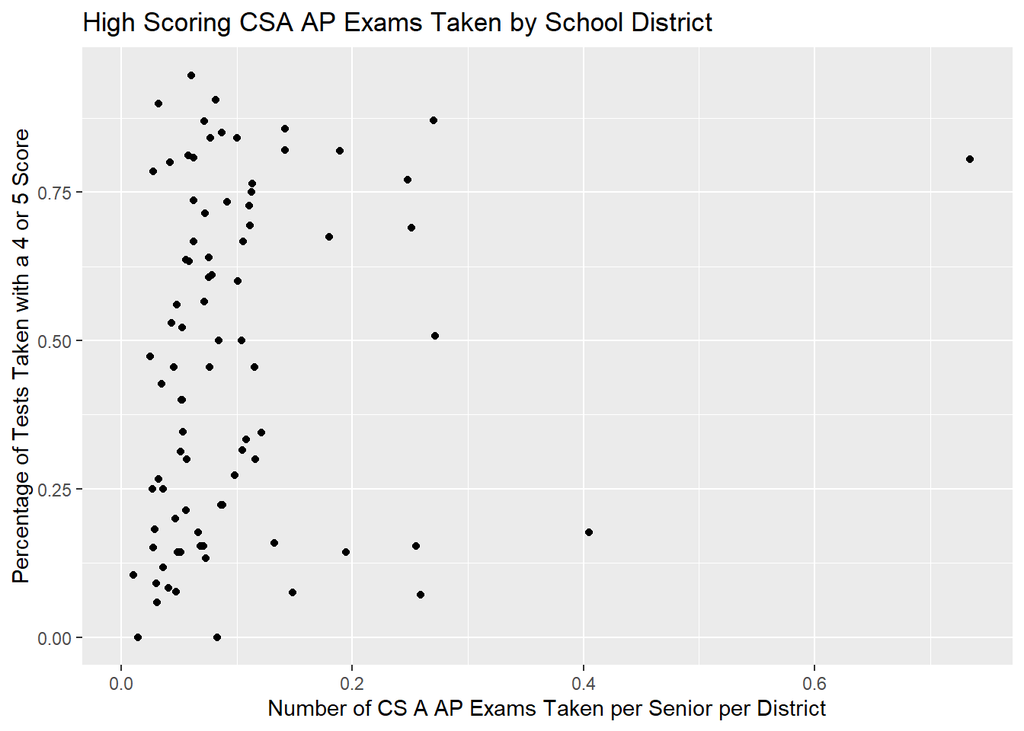

```r
#These are exploration plots to visualize the new columns and their relationship to other variables of interest.
CSA_all2 %>%
  ggplot(aes(x = Exams_per_senior, y = percent_4_5)) + geom_point() + labs(title = "High Scoring CSA AP Exams Taken by School District", y = "Percentage of Tests Taken with a 4 or 5 Score", x = "Number of CS A AP Exams Taken per Senior per District")
```

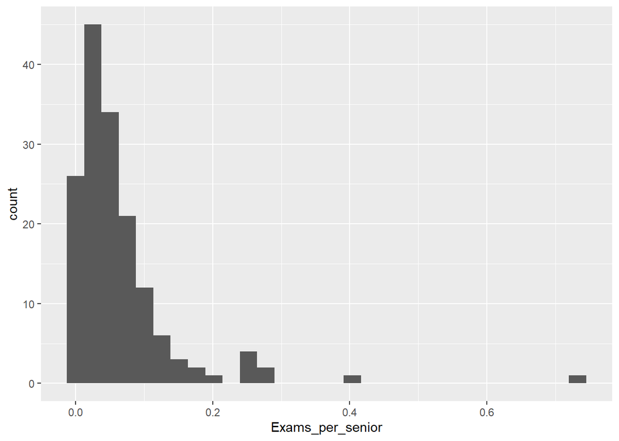

```r
CSA_all2 %>%
  ggplot(aes(x = Exams_per_senior)) + geom_histogram()
```

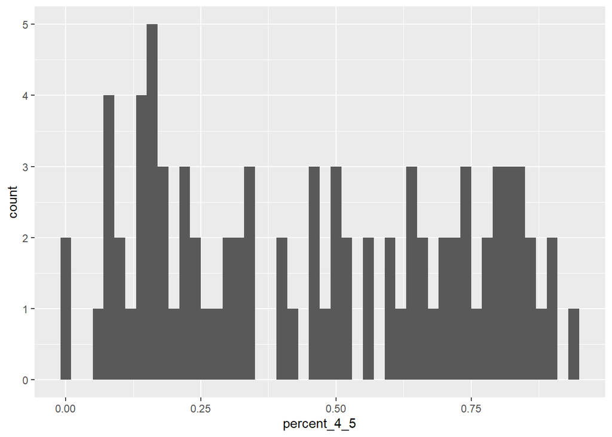

```r
CSA_all2 %>%
  ggplot(aes(x = percent_4_5)) + geom_histogram(binwidth = .02)
```

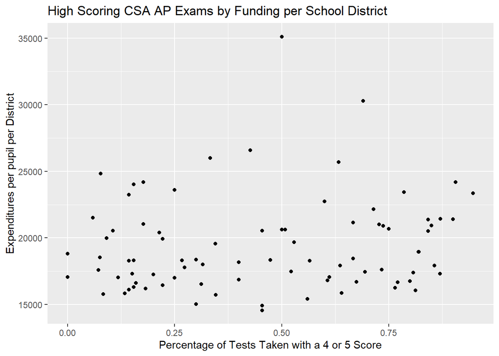

```r
CSA_all2 %>%
  ggplot(aes(x = percent_4_5, y = total_expenditures_per_pupil)) + geom_point()+ labs(title = "High Scoring CSA AP Exams by Funding per School District", x = "Percentage of Tests Taken with a 4 or 5 Score", y = "Expenditures per pupil per District")
```

A couple of observations from the plots above are intriguing. First, plotting exams per senior against the high passing rates shows a weak correlation as other previous plots, but what is interesting in this version are those potential outliers. I want to dive deeper into those data points where more than 20% of the senior cohort are taking the AP exam. Second, the distributions of the two new variables I added, Exams per senior and percentage of 4 and 5 scores, are unexpectedly different. There is a right skewed distribution for the ratio of exams per senior, with some pretty clear outliers, and this plot does not include any NA values. The plot for the percentage of high passing scores is quite different. Due to the lack of detail for those schools with fewer than 10 exams taken, only half of the districts are represented, and perhaps as a result, the histogram for percentage of test takers earning a 4 or a 5 lacks a normal distribution. This seems to suggest that students from school districts with more than 10 exams taken could have any rate of high passing on the CSA exam. To understand this result better, I want to look more closely at the school districts with score 4/5 rates above 50% and see if I notice anything that they have in common.

```r
high_scoring_districts <- filter(CSA_all2, percent_4_5 > .5)
summary(high_scoring_districts)
```

```
 District Name      District Code     In-District Expenditures
 Length:39          Min.   :  90000   Min.   : 16072974
 Class :character   1st Qu.:1280000   1st Qu.: 45945582
 Mode  :character   Median :1990000   Median : 68264324
                    Mean   :2829744   Mean   : 77581912
                    3rd Qu.:3395000   3rd Qu.: 96254250
                    Max.   :7750000   Max.   :270427954
                                      NA's   :1
 Total In-district FTEs In-District Expenditures per Pupil Total Expenditures
 Min.   :  963.9        Min.   :14597                      Min.   : 16072974
 1st Qu.: 2324.7        1st Qu.:16137                      1st Qu.: 49140566
 Median : 3945.4        Median :17924                      Median : 73810050
 Mean   : 4140.2        Mean   :18682                      Mean   : 84735629
 3rd Qu.: 5453.7        3rd Qu.:20246                      3rd Qu.:105565107
 Max.   :12019.4        Max.   :29320                      Max.   :285876115
 NA's   :1              NA's   :1                          NA's   :1
 Total Pupil FTEs  total_expenditures_per_pupil CSATestsTaken
 Min.   :  963.9   Min.   :15412                Min.   : 11.00
 1st Qu.: 2428.7   1st Qu.:17339                1st Qu.: 19.00
 Median : 4240.6   Median :18961                Median : 26.00
 Mean   : 4299.2   Mean   :19655                Mean   : 32.18
 3rd Qu.: 5571.4   3rd Qu.:21316                3rd Qu.: 36.00
 Max.   :12200.7   Max.   :30296                Max.   :147.00
 NA's   :1         NA's   :1
   one_score       two_score       three_score       four_score
 Min.   :0.000   Min.   : 0.000   Min.   : 1.000   Min.   : 3.000
 1st Qu.:0.000   1st Qu.: 0.000   1st Qu.: 2.000   1st Qu.: 6.000
 Median :1.000   Median : 1.000   Median : 4.000   Median : 8.000
 Mean   :1.538   Mean   : 1.923   Mean   : 4.718   Mean   : 9.436
 3rd Qu.:2.000   3rd Qu.: 3.000   3rd Qu.: 7.000   3rd Qu.:10.000
 Max.   :6.000   Max.   :12.000   Max.   :15.000   Max.   :44.000

   five_score      percent_12     percent_345     Senior_cohort
 Min.   : 0.00   Min.   : 0.00   Min.   : 70.00   Min.   :  49.0
 1st Qu.: 7.00   1st Qu.: 3.95   1st Qu.: 81.80   1st Qu.: 227.0
 Median :12.00   Median : 9.10   Median : 90.90   Median : 319.0
 Mean   :14.56   Mean   :11.11   Mean   : 88.89   Mean   : 340.6
 3rd Qu.:19.00   3rd Qu.:18.20   3rd Qu.: 96.05   3rd Qu.: 437.0
 Max.   :84.00   Max.   :30.00   Max.   :100.00   Max.   :1009.0

  percent_grad   percent_stillinschool percent_nongrad   percentHSequiv
 Min.   :81.00   Min.   :0.300         Min.   :0.00000   Min.   :0.0000
 1st Qu.:95.00   1st Qu.:1.550         1st Qu.:0.00000   1st Qu.:0.0000
 Median :96.90   Median :2.000         Median :0.00000   Median :0.0000
 Mean   :95.62   Mean   :2.621         Mean   :0.07179   Mean   :0.2026
 3rd Qu.:97.95   3rd Qu.:3.150         3rd Qu.:0.00000   3rd Qu.:0.2500
 Max.   :99.40   Max.   :7.300         Max.   :0.80000   Max.   :2.1000

 percentDroppedout Exams_per_senior   percent_4_5      na.rm
 Min.   : 0.00     Min.   :0.02775   Min.   :0.5079   Mode:logical
 1st Qu.: 0.20     1st Qu.:0.06165   1st Qu.:0.6382   TRUE:39
 Median : 0.70     Median :0.07826   Median :0.7368
 Mean   : 1.49     Mean   :0.11895   Mean   :0.7318
 3rd Qu.: 1.65     3rd Qu.:0.11300   3rd Qu.:0.8199
 Max.   :10.60     Max.   :0.73469   Max.   :0.9474
```

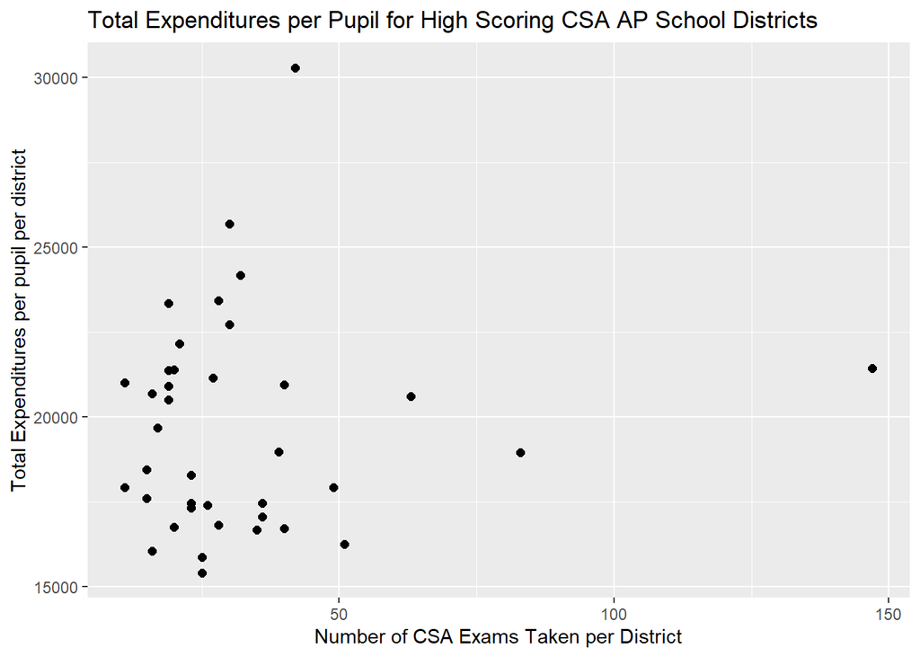

```r
#above I am filtering the dataset to include just those districts with scoring rates of a 4 or a 5 that are greater than 50% and then displaying a summary table for each column.
high_scoring_districts %>%
 ggplot(aes(x = CSATestsTaken, y = total_expenditures_per_pupil)) + geom_point(size = 2) + labs(title = "Total Expenditures per Pupil for High Scoring CSA AP School Districts", y = "Total Expenditures per pupil per district", x = "Number of CSA Exams Taken per District")
```

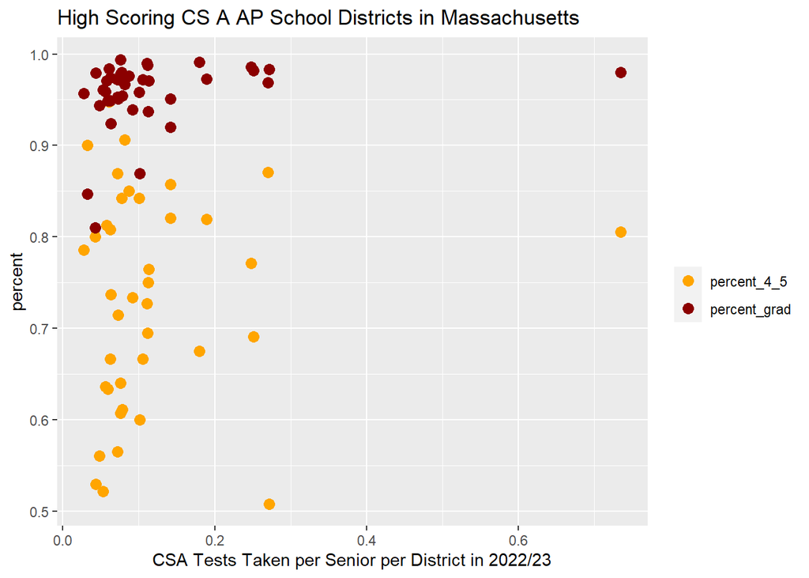

```r
high_scoring_districts %>%
    ggplot(aes(x = Exams_per_senior)) +
    geom_point(size = 3, aes(y= percent_4_5,  color = "percent_4_5")) +

    geom_point(size = 3, aes(y= (percent_grad/100), color = "percent_grad"))+
    labs(title = "High Scoring CS A AP School Districts in Massachusetts") +
  scale_colour_manual("", values = c("percent_4_5" = "orange", "percent_grad" = "darkred")) +
  xlab("CSA Tests Taken per Senior per District in 2022/23") +
  ylab("percent")
```

There are not a lot of conclusions to draw from these last two plots, but there are some interesting observations that I can make. The closer a school gets to having 1 AP exam per senior in schools where more than half of the test takers earn a high passing score of a 4 or a 5, the higher the graduation rate for that school. This correlation is weak so there is no linear relationship here - it isn’t a perfect increase per unit x vs y. But, we can say that all students in this high passing category are also at schools with above a 90% graduation rate, except for 3. We can also say that there is a less likely correlation between the number of exams per senior and when a school district is more likely to have half or more test takers in this high scoring area. We see high scoring majorities even in districts where relatively few exams are taken with respect to the size of the senior cohort.

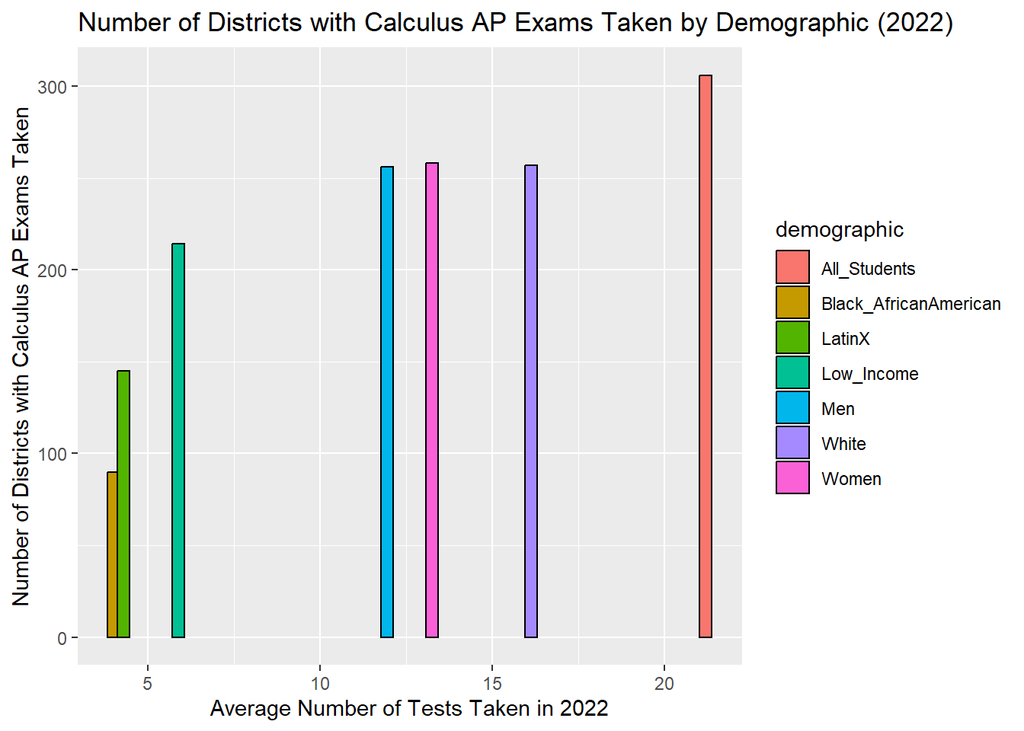

```r
calc_means_2022 <-read.csv("Summary_Means.csv")
CSA_means_2022 <- read.csv("CSA_Summary_Means2022.csv")
calc_means_2022["demographic"][calc_means_2022["demographic"] == "CalcAll"] <- "All_Students"
calc_means_2022["demographic"][calc_means_2022["demographic"] == "Calc_Men"] <- "Men"
calc_means_2022["demographic"][calc_means_2022["demographic"] == "Calc_women"] <- "Women"
calc_means_2022["demographic"][calc_means_2022["demographic"] == "Calc_lowI"] <- "Low_Income"
calc_means_2022["demographic"][calc_means_2022["demographic"] == "Calc_wh"] <- "White"
calc_means_2022["demographic"][calc_means_2022["demographic"] == "Calc_bl"] <- "Black_AfricanAmerican"
calc_means_2022["demographic"][calc_means_2022["demographic"] == "Calc_lnx"] <- "LatinX"

CSA_means_2022["demographic"][CSA_means_2022["demographic"] == "CSA_All"] <- "All_Students"
CSA_means_2022["demographic"][CSA_means_2022["demographic"] == "CSA_men"] <- "Men"
CSA_means_2022["demographic"][CSA_means_2022["demographic"] == "CSA_women"] <- "Women"
CSA_means_2022["demographic"][CSA_means_2022["demographic"] == "CSA_lowI"] <- "Low_Income"
CSA_means_2022["demographic"][CSA_means_2022["demographic"] == "CSA_wh"] <- "White"
CSA_means_2022["demographic"][CSA_means_2022["demographic"] == "CSA_bl"] <- "Black_AfricanAmerican"
CSA_means_2022["demographic"][CSA_means_2022["demographic"] == "CSA_lnX"] <- "LatinX"

library (dplyr)
calc_means_2022 %>%
  ggplot (aes(y = number_districts_exams, x = mean_number_tt, fill = demographic)) + geom_bar(width = .35,  color = "black", stat="identity")  + ggtitle("Number of Districts with Calculus AP Exams Taken by Demographic (2022)") +  xlab ("Average Number of Tests Taken in 2022") + ylab("Number of Districts with Calculus AP Exams Taken")+ scale_color_gradientn(colors = rainbow (7))
```

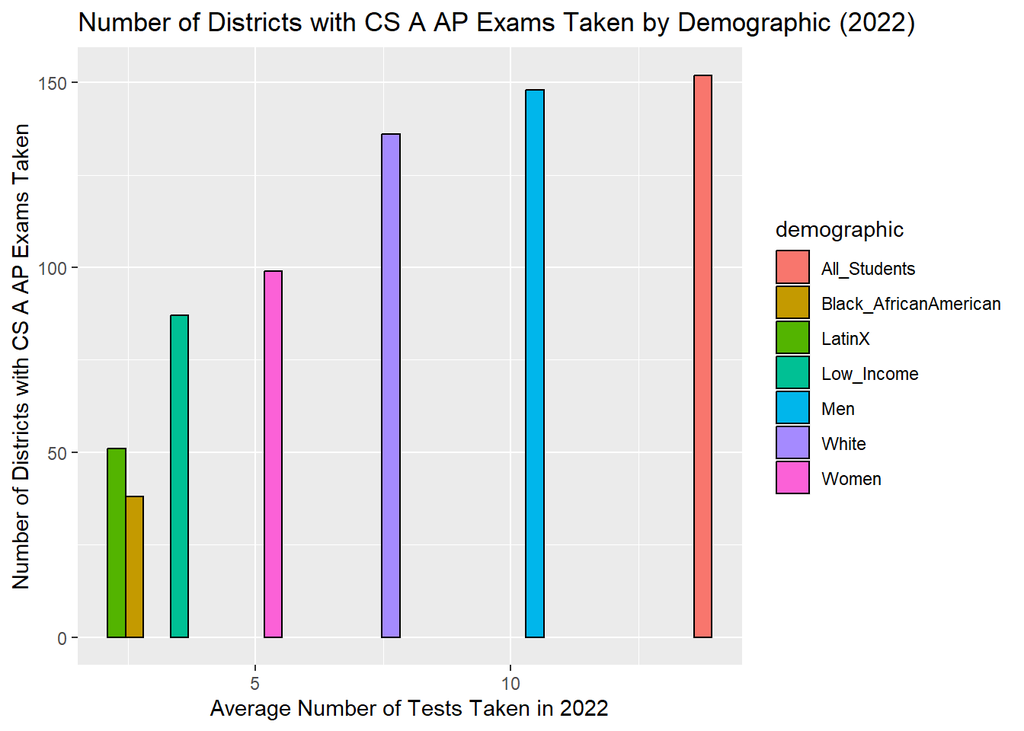

```r
CSA_means_2022 %>%
  ggplot (aes(y = number_districts_exams, x = mean_number_tt, fill = demographic)) + geom_bar(width = .35,  color = "black", stat="identity")  + ggtitle("Number of Districts with CS A AP Exams Taken by Demographic (2022)") +  xlab ("Average Number of Tests Taken in 2022") + ylab("Number of Districts with CS A AP Exams Taken")+ scale_color_gradientn(colors = rainbow (7))
```

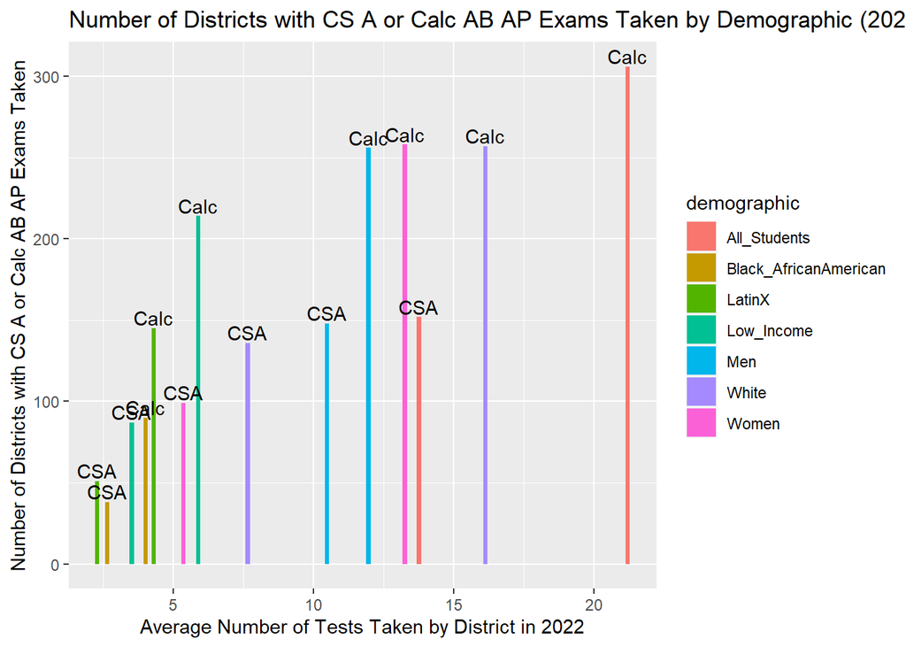

**Conclusion** To me, the data story in this project is one of access and opportunity. When CS AP exams are taken in a school district, a significant proportion, perhaps as many as half, are just as likely to earn high passing grades oa not, and through the other data explorations, there doesn’t seem to be a strong correlation between any variable related to exam success. This is an important observation as a significant meta analysis of multiple datasets related to learning, learning speed, and achievement gaps has found that all students learn at about the same rate and that achievement gaps are the result of lack of access to opportunities for practice/learning experiences and not due to differences in learning rates (Koedinger et al 2023).

Another important observation is that of the 6 school districts with the highest number of CS A AP exams taken, 4 have significantly smaller senior cohorts when compared to the other 2, and, are overwhelmingly wealthy when looking at average home selling costs and median family income. The top exam district has a median single family home price of $975K and a median family income of over $200,000. It also is graded as less diverse overall and as having a very low (~5%) free and reduced lunch rate among students in that district (see https://www.niche.com/k12/d/lexington-public-schools-ma/ for more details). My conclusions from this project are that students do well on the CS A AP exam, regardless of expenditures per student, size of cohort, or number of exams taken. However, there is a disproportionate amount of access to the CS A AP in districts primarily populated by wealthy and very wealthy Massachusetts residents. This observation coupled with the research on the need to address lack of opportunity on closing achievement gaps emerges as driving a data story of CS AP access that is skewed toward students occupying the wealthiest communities in the state.

**Datasets Used** Dese. (2023, December 14). 2022-23 Advanced Placement Performance. School and District Profiles. Dese. https://profiles.doe.mass.edu/statereport/ap.aspx

Dese. (2023, March 9). 2022 Graduation Rate Report (District) for All Students 4-Year Graduation Rate. School and District Profiles. https://profiles.doe.mass.edu/statereport/gradrates.aspx

Dese. (2024, January 18). Per Pupil Expenditures, All Funds. School and District Profiles. Dese. https://profiles.doe.mass.edu/statereport/ppx.aspx

**Works Consulted**

Freeman S, Eddy SL, McDonough M, Smith MK, Okoroafor N, Jordt H, Wenderoth MP. Active learning increases student performance in science, engineering, and mathematics. Proc Natl Acad Sci U S A. 2014; 111:8410-8415.

Kuh, G. D. (2008). Excerpt from high-impact educational practices: What they are, who has access to them, and why they matter. Association of American Colleges and Universities. Martha J. Bailey and Susan M. Dynarski, “Inequality in Postsecondary Attainment,” 2011. In Greg Duncan and Richard Murnane, eds., Whither Opportunity: Rising Inequality, Schools, and Children’s Life Chances, pp. 117-132. New York: Russell Sage Foundation.

Soria, K.M. & Stebleton, M.J. (2012). First-generation students’ academic engagement and retention, Teaching in Higher Education, 17(6), 673-685, DOI: 10.1080/13562517.2012.666735

Swail, W. S. (2003). Retaining Minority Students in Higher Education: A Framework for Success. ASHE-ERIC Higher Education Report. Jossey-Bass Higher and Adult Education Series. Jossey-Bass: San Francisco, CA.

Thayer, P. (2000). Retention of students from first-generation and low-income backgrounds. The Journal of the Council for Opportunity in Education, Washington, DC

Tinto, V. (2006). Research and practice of student retention: What next? Journal of College Student Retention, 8(1), 1-19.

Watkins J, Mazur E. Retaining students in science, technology, engineering, and mathematics (STEM) majors. Journal of College Science Teaching. 2013; 42:36-41.

**Works Cited**

Niche.com. (2024). Lexington Public Schools. Niche.com. https://www.niche.com/k12/d/lexington-public-schools-ma/

Koedinger, K. R., Carvalho, P. F., Liu, R., & McLaughlin, E. A. (2023). An astonishing regularity in student learning rate. Proceedings of the National Academy of Sciences, 120(13), e2221311120.

R Core Team (2021). R: A language and environment for statistical computing. R Foundation for Statistical Computing, Vienna, Austria. https://www.R-project.org/.